# **Unicorn Starups and Venture Captial**

# **Question**

I am a venture capitalist looking to make some investments in some untapped emerging markets and hence need you to provide me insights. Provide me a list of 5 companies to spend my money on, based on the following criteria: (1) reached unicorn status recently (2) operate in a country with few investments (3) operate in an niche but still profitable sector.

# **Abstract**

# **Data Cleaning + Processing**

```python
import pandas as pd
import seaborn as sns
import matplotlib.pyplot as plt
import statsmodels.api as sm
from sklearn.cluster import KMeans
from sklearn.preprocessing import MinMaxScaler


data = pd.read_csv("/content/drive/MyDrive/unicorns till sep 2022.csv")
data = data.dropna().drop_duplicates()
data.rename(columns={'Valuation ($B)': 'Valuation'}, inplace=True)
print(data.columns)


for column in data.columns:
    if column not in ['Valuation', 'Date Joined']:
        data[column] = data[column].astype('string')


data['Valuation'] = data['Valuation'].replace({'\$': '', ',': ''}, regex=True)
data['Valuation'] = data['Valuation'].str.replace(r'\.\d+', '', regex=True).astype(float)
data['Valuation'] = data['Valuation'] * 1e9


data['Date Joined'] = pd.to_datetime(data['Date Joined'].astype(str), errors='coerce')
reference_date = pd.Timestamp.now()
data['Days Since Joined'] = (reference_date - data['Date Joined']).dt.days


data['Investors'] = data['Investors'].apply(lambda x: x.split(', '))
def distinct_investors(row):
    country_investors = set()
    for country_row in data[data['Country'] == row['Country']]['Investors']:
        country_investors.update(country_row)
    return len(country_investors)


data['Distinct Investors in Country'] = data.apply(distinct_investors, axis=1)
data['Industry Popularity Rank'] = data['Industry'].map(data['Industry'].value_counts().rank(ascending=False)).astype(int)


data.info()
display(data)
```

```
Index(['Company', 'Valuation', 'Date Joined', 'Country', 'City ', 'Industry',
       'Investors'],
      dtype='object')
<class 'pandas.core.frame.DataFrame'>
Int64Index: 1168 entries, 0 to 1185
Data columns (total 10 columns):
 #   Column                         Non-Null Count  Dtype
---  ------                         --------------  -----
 0   Company                        1168 non-null   string
 1   Valuation                      1168 non-null   float64
 2   Date Joined                    1168 non-null   datetime64[ns]
 3   Country                        1168 non-null   string
 4   City                           1168 non-null   string
 5   Industry                       1168 non-null   string
 6   Investors                      1168 non-null   object
 7   Days Since Joined              1168 non-null   int64
 8   Distinct Investors in Country  1168 non-null   int64
 9   Industry Popularity Rank       1168 non-null   int64
dtypes: datetime64[ns](1), float64(1), int64(3), object(1), string(4)
memory usage: 100.4+ KB
```

|  | Company | Valuation | Date Joined | Country | City | Industry | Investors | Days Since Joined | Distinct Investors in Country | Industry Popularity Rank |
| --- | --- | --- | --- | --- | --- | --- | --- | --- | --- | --- |
| 0 | ByteDance | 1.400000e+11 | 2017-04-07 | China | Beijing | Artificial intelligence | [Sequoia Capital China, SIG Asia Investments, ... | 2412 | 278 | 5 |
| 1 | SpaceX | 1.270000e+11 | 2012-12-01 | United States | Hawthorne | Other | [Founders Fund, Draper Fisher Jurvetson, Rothe... | 4000 | 744 | 6 |
| 2 | SHEIN | 1.000000e+11 | 2018-07-03 | China | Shenzhen | E-commerce & direct-to-consumer | [Tiger Global Management, Sequoia Capital Chin... | 1960 | 278 | 3 |
| 3 | Stripe | 9.500000e+10 | 2014-01-23 | United States | San Francisco | Fintech | [Khosla Ventures, LowercaseCapital, capitalG] | 3582 | 744 | 1 |
| 4 | Canva | 4.000000e+10 | 2018-01-08 | Australia | Surry Hills | Internet software & services | [Sequoia Capital China, Blackbird Ventures, Ma... | 2136 | 19 | 2 |
| ... | ... | ... | ... | ... | ... | ... | ... | ... | ... | ... |
| 1181 | LeadSquared | 1.000000e+09 | 2022-06-21 | India | Bengaluru | Internet software & services | [Gaja Capital Partners, Stakeboat Capital, Wes... | 511 | 116 | 2 |
| 1182 | FourKites | 1.000000e+09 | 2022-06-21 | United States | Chicago | Supply chain, logistics, & delivery | [Hyde Park Venture Partners, Bain Capital Vent... | 511 | 744 | 6 |
| 1183 | VulcanForms | 1.000000e+09 | 2022-07-05 | United States | Burlington | Supply chain, logistics, & delivery | [Eclipse Ventures, D1 Capital Partners, Indust... | 497 | 744 | 6 |
| 1184 | SingleStore | 1.000000e+09 | 2022-07-12 | United States | San Francisco | Data management & analytics | [Google Ventures, Accel, Data Collective] | 490 | 744 | 9 |
| 1185 | Unstoppable Domains | 1.000000e+09 | 2022-07-27 | United States | Las Vegas | Internet software & services | [Boost VC, Draper Associates, Gaingels] | 475 | 744 | 2 |

1168 rows × 10 columns

# **Exploratory Data Analysis (EDA)**

**Valuation Distribution**

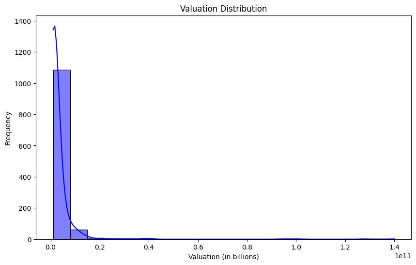

```python
plt.figure(figsize=(10, 6))
sns.histplot(data['Valuation'], kde=True, color='blue', bins=20)
plt.title('Valuation Distribution')
plt.xlabel('Valuation (in billions)')
plt.ylabel('Frequency')

plt.show()
```

**Mean Valuation Analysis**

[figure not shown]

```python
data['Normalized_Valuation'] = data.groupby('Industry')['Valuation'].transform(lambda x: (x - x.mean()) / x.std())
industry_mean_valuation = data.groupby('Industry')['Normalized_Valuation'].mean().sort_values(ascending=False)
top_10_industries = industry_mean_valuation.head(10)
plt.figure(figsize=(10, 6))
top_10_industries.plot(kind='bar', color='skyblue')
plt.title('Top 10 Industries with Highest Mean Valuation (Z-Score Normalized)')
plt.xlabel('Industry')
plt.ylabel('Mean Valuation')
plt.xticks()
plt.tight_layout()
plt.show()
```

**Most/Least Popular Unicorn Startup Sectors**

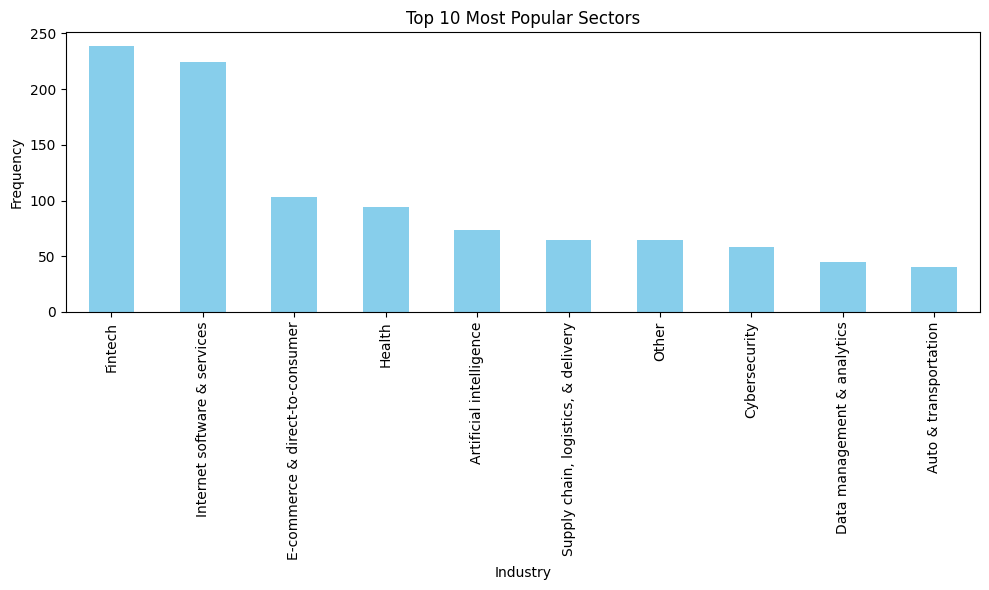

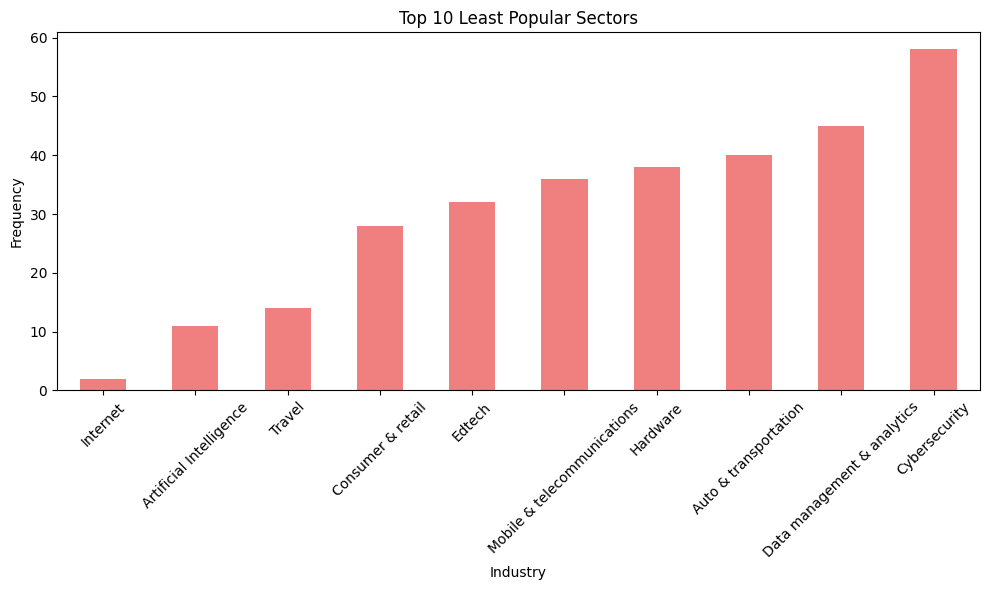

```python
top_10_popular = data['Industry'].value_counts().nlargest(10)

plt.figure(figsize=(10, 6))
top_10_popular.plot(kind='bar', color='skyblue')
plt.title('Top 10 Most Popular Sectors')
plt.xlabel('Industry')
plt.ylabel('Frequency')
plt.xticks()
plt.tight_layout()
plt.show()


bottom_10_least_popular = data['Industry'].value_counts().nsmallest(10)

plt.figure(figsize=(10, 6))
bottom_10_least_popular.plot(kind='bar', color='lightcoral')
plt.title('Top 10 Least Popular Sectors')
plt.xlabel('Industry')
plt.ylabel('Frequency')
plt.xticks(rotation=45)
plt.tight_layout()
plt.show()
```

**Top/Lowest Investor Count per Country**

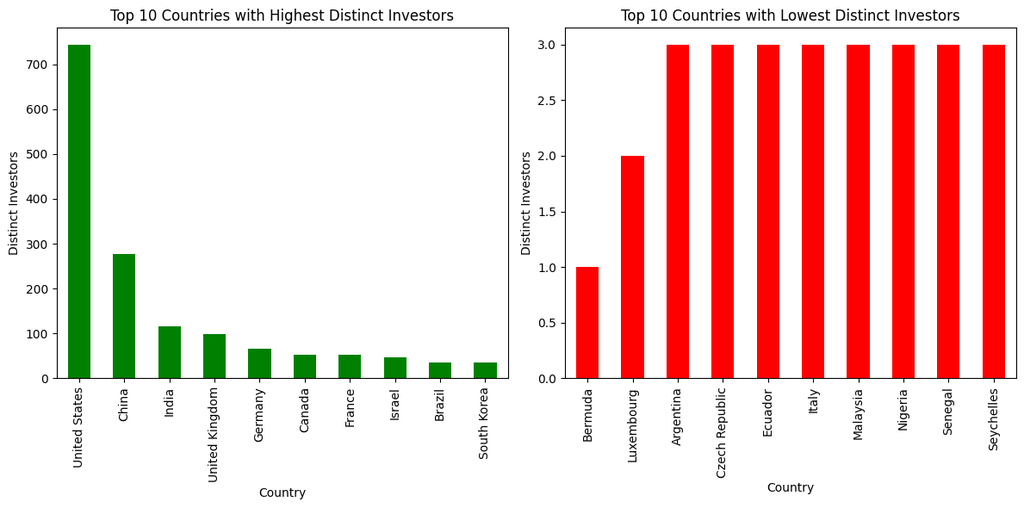

```python
top_10_highest_countries = data.groupby('Country')['Distinct Investors in Country'].max().nlargest(10)
top_10_lowest_countries = data.groupby('Country')['Distinct Investors in Country'].max().nsmallest(10)
plt.figure(figsize=(12, 6))

plt.subplot(1, 2, 1)
top_10_highest_countries.plot(kind='bar', color='green')
plt.title('Top 10 Countries with Highest Distinct Investors')
plt.xlabel('Country')
plt.ylabel('Distinct Investors')

plt.subplot(1, 2, 2)
top_10_lowest_countries.plot(kind='bar', color='red')
plt.title('Top 10 Countries with Lowest Distinct Investors')
plt.xlabel('Country')
plt.ylabel('Distinct Investors')

plt.tight_layout()
plt.show()
```